# Developmental Experiences: Shaping Students’ Experience In Academic Environments

Author

Kylee Klinger

## Introduction & Overview

#### Context

The report documents the workflow from the original Qualtrics survey data to study variables, scale scoring, descriptive statistics, reliability checks, and final statistical analyses.

The purpose of this report is to make the analysis process clear so that a reader (of the manuscript-style research paper) can understand how the data were prepared and how the final results were produced.

#### Study Overview

The current study examined the effects of feedback type (autonomy-supportive or controlling) on students’ self-efficacy and achievement motivation, and how parental warmth influences these relationships.

Design:

- 1 manipulated independent variable (autonomy-supportive or controlling feedback)
- 1 moderating variable (high or low perceived parental warmth)
- 2 dependent variables (self-efficacy and achievement motivation)

The primary analyses in this report used two 2 × 2 ANOVAs to test the main and interaction effects of feedback type and parental warmth on self-efficacy and achievement motivation.

## Setup and Software Environment

#### Load Packages

This section loads the tidyverse, psych, afex, and emmeans packages used to prepare the raw data, create scale scores, run statistical analyses, and generate figures for the current study.

```r
library(tidyverse)
library(psych)
library(afex)
library(emmeans)
```

## Data Source & Preparation

#### Load Data

Loading Qualtrics survey data from “data” folder under “lab_data”.

```r
lab_data <- read.csv("data/Group 7 Developmental Autonomy_Clean.csv")
names(lab_data)
```

```
 [1] "ResponseId"          "DistributionChannel" "Consent"
 [4] "Control.Writing"     "Autonomy.Writing"    "GSE._1"
 [7] "GSE._2"              "GSE._3"              "GSE._4"
[10] "GSE._5"              "GSE._6"              "GSE._7"
[13] "GSE._8"              "GSE._9"              "GSE._10"
[16] "RAMS._1"             "RAMS._2"             "RAMS._3"
[19] "RAMS._4"             "RAMS._5"             "RAMS._6"
[22] "RAMS._7"             "RAMS._8"             "RAMS._9"
[25] "RAMS._10"            "RAMS._11"            "RAMS._12"
[28] "RAMS._13"            "RAMS._14"            "PAQ1_1"
[31] "PAQ1_2"              "PAQ1_3"              "PAQ1_4"
[34] "PAQ1_5"              "PAQ1_6"              "PAQ1_7"
[37] "PAQ1_8"              "PAQ1_9"              "PAQ1_10"
[40] "PAQ1_11"             "PAQ1_12"             "PAQ1_13"
[43] "PAQ1_14"             "PAQ1_15"             "PAQ2_1"
[46] "PAQ2_2"              "PAQ2_3"              "PAQ2_4"
[49] "PAQ2_5"              "PAQ2_6"              "PAQ2_7"
[52] "PAQ2_8"              "PAQ2_9"              "PAQ2_10"
[55] "PAQ2_11"             "PAQ2_12"             "PAQ2_13"
[58] "PAQ2_14"             "PAQ2_15"             "Age"
[61] "Gender"              "Gender_4_TEXT"       "Year"
[64] "Year_5_TEXT"         "Debrief"             "Condition"
```

#### Data Exclusions

Excluding participants who did not complete the survey.

```r
#excluding participants w/ missing data
lab_data <- lab_data %>%
  filter(
    if_all(GSE._1:PAQ2_15,
           ~!is.na(.)
           ))
```

#### Create Participant ID

Creating a unique ID for each participant.

```r
# Create a unique ID for each participant
lab_data <- lab_data %>%
  mutate(id = row_number()) # assigns sequential ID values
```

#### Creating & Listing Study Variables

Listing and defining relevant study variables including consent, feedback type assignment (IV), GSE item scores (DV1), RAMS item scores (DV2), PAQ item scores (Moderator), age, gender, and year in college.

```r
lab_vars <- c(
  "Consent",
  "Control.Writing",
  "Autonomy.Writing",

  "GSE._1",
  "GSE._2",
  "GSE._3",
  "GSE._4",
  "GSE._5",
  "GSE._6",
  "GSE._7",
  "GSE._8",
  "GSE._9",
  "GSE._10",

  "RAMS._1",
  "RAMS._2",
  "RAMS._3",
  "RAMS._4",
  "RAMS._5",
  "RAMS._6",
  "RAMS._7",
  "RAMS._8",
  "RAMS._9",
  "RAMS._10",
  "RAMS._11",
  "RAMS._12",
  "RAMS._13",
  "RAMS._14",

  "PAQ1_1",
  "PAQ1_2",
  "PAQ1_3",
  "PAQ1_4",
  "PAQ1_5",
  "PAQ1_6",
  "PAQ1_7",
  "PAQ1_8",
  "PAQ1_9",
  "PAQ1_10",
  "PAQ1_11",
  "PAQ1_12",
  "PAQ1_13",
  "PAQ1_14",
  "PAQ1_15",
  "PAQ2_1",
  "PAQ2_2",
  "PAQ2_3",
  "PAQ2_4",
  "PAQ2_5",
  "PAQ2_6",
  "PAQ2_7",
  "PAQ2_8",
  "PAQ2_9",
  "PAQ2_10",
  "PAQ2_11",
  "PAQ2_12",
  "PAQ2_13",
  "PAQ2_14",
  "PAQ2_15",

  "Age",
  "Gender",
  "Year",
  "Condition"
)
```

#### Converting data to numeric values

Converting General Self-Efficacy, Ray’s Achievement Motivation and Parental Authority Questionnaire answers to numeric values for further statistical analysis.

```r
# Convert all variables to numeric format
lab_data <- lab_data %>%
  mutate(across(GSE._1:PAQ2_15, as.numeric)) # ensures numeric type for all variables
```

#### Count Experimental Condition

Counting the number of participants in each manipulated condition.

```r
# Verify condition counts
lab_data %>%
  count(Condition) # counts observations in each condition
```

```
  Condition  n
1  Autonomy 38
2   Control 38
```

## Defining Scale Items & Creating Scales

#### Defining Ray’s Achievement Motivation reverse-coded items

Reverse-coding items 1, 2, 7, 11, 12, 13, & 14 on RAM scale to transform necessary item scores before scale score calculations. RAM items are scored 1-3, therefore reverse-coded item scores were subtracted from 4 to calculate the correct values.

```r
# Reverse-code selected RAM items
lab_data <- lab_data %>%
  mutate(
    RAMS._1r = 4 - RAMS._1, # reverse-codes RAMS._1
    RAMS._2r = 4 - RAMS._2, # reverse-codes RAMS._2
    RAMS._7r = 4 - RAMS._7, # reverse-codes RAMS._7
    RAMS._11r = 4 - RAMS._11, #reverse-codes RAMS._11
    RAMS._12r = 4 - RAMS._12, #reverse-codes RAMS._12
    RAMS._13r = 4 - RAMS._13, #reverse-codes RAMS._13
    RAMS._14r = 4 - RAMS._14, #reverse-codes RAMS._14
    )
```

#### Defining GSE scale

Confirming all GSE scale items are in the data.

```r
# Define GSE scale items
GSE_items <- c("GSE._1","GSE._2","GSE._3","GSE._4","GSE._5","GSE._6","GSE._7","GSE._8","GSE._9","GSE._10"
               )
# Check that all items exist in dataset
setNames(GSE_items %in% names(lab_data), GSE_items) # verifies item presence
```

```
 GSE._1  GSE._2  GSE._3  GSE._4  GSE._5  GSE._6  GSE._7  GSE._8  GSE._9 GSE._10
   TRUE    TRUE    TRUE    TRUE    TRUE    TRUE    TRUE    TRUE    TRUE    TRUE
```

#### Defining RAM Scale

Confirming all RAM scale items are in the data.

```r
# Define RAM scale items
RAM_items <- c( "RAMS._1r","RAMS._2r","RAMS._3","RAMS._4","RAMS._5","RAMS._6","RAMS._7r","RAMS._8","RAMS._9","RAMS._10","RAMS._11r","RAMS._12r","RAMS._13r","RAMS._14r"
               )
# Check that all items exist in dataset
setNames(RAM_items %in% names(lab_data), RAM_items) # verifies item presence
```

```
 RAMS._1r  RAMS._2r   RAMS._3   RAMS._4   RAMS._5   RAMS._6  RAMS._7r   RAMS._8
     TRUE      TRUE      TRUE      TRUE      TRUE      TRUE      TRUE      TRUE
  RAMS._9  RAMS._10 RAMS._11r RAMS._12r RAMS._13r RAMS._14r
     TRUE      TRUE      TRUE      TRUE      TRUE      TRUE
```

#### Defining PAQ Subscales

##### Permissive items

Confirming all permissive PAQ subscale items are in the data.

```r
#permissive PAQ items
PerPAQ_items <- c("PAQ1_1", "PAQ1_6", "PAQ1_10", "PAQ1_13", "PAQ1_14", "PAQ2_2", "PAQ2_4", "PAQ2_6", "PAQ2_9", "PAQ2_13")

# Check that all items exist in dataset
setNames(PerPAQ_items %in% names(lab_data), PerPAQ_items) # verifies item presence
```

```
 PAQ1_1  PAQ1_6 PAQ1_10 PAQ1_13 PAQ1_14  PAQ2_2  PAQ2_4  PAQ2_6  PAQ2_9 PAQ2_13
   TRUE    TRUE    TRUE    TRUE    TRUE    TRUE    TRUE    TRUE    TRUE    TRUE
```

##### Authoritarian items

Confirming all authoritarian PAQ subscale items are in the data.

```r
#authoritarian PAQ items
ATNPAQ_items <- c("PAQ1_2", "PAQ1_3", "PAQ1_7", "PAQ1_9", "PAQ1_12", "PAQ2_1", "PAQ2_3", "PAQ2_10", "PAQ2_11", "PAQ2_14")

# Check that all items exist in dataset
setNames(ATNPAQ_items %in% names(lab_data), ATNPAQ_items) # verifies item presence
```

```
 PAQ1_2  PAQ1_3  PAQ1_7  PAQ1_9 PAQ1_12  PAQ2_1  PAQ2_3 PAQ2_10 PAQ2_11 PAQ2_14
   TRUE    TRUE    TRUE    TRUE    TRUE    TRUE    TRUE    TRUE    TRUE    TRUE
```

##### Authoritative items

Confirming all authoritative PAQ subscale items are in the data.

```r
#authoritative PAQ items
ATEPAQ_items <-c("PAQ1_4", "PAQ1_5", "PAQ1_8", "PAQ1_11", "PAQ1_15", "PAQ2_5", "PAQ2_7", "PAQ2_8", "PAQ2_12", "PAQ2_15")

# Check that all items exist in dataset
setNames(ATEPAQ_items %in% names(lab_data), ATEPAQ_items) # verifies item presence
```

```
 PAQ1_4  PAQ1_5  PAQ1_8 PAQ1_11 PAQ1_15  PAQ2_5  PAQ2_7  PAQ2_8 PAQ2_12 PAQ2_15
   TRUE    TRUE    TRUE    TRUE    TRUE    TRUE    TRUE    TRUE    TRUE    TRUE
```

## Calculating Scale Scores

#### GSE scale scores

Calculating GSE scale scores and ensuring no scores are missing.

```r
# Compute GSE scale as the row sum of items
lab_data <- lab_data %>%
  mutate(GSE_scale = rowSums(as.matrix(across(all_of(GSE_items))), na.rm = TRUE) # calculates scale score
         )
# Check proportion of missing scale scores
mean(is.na(lab_data$GSE_scale)) # should be close to 0
```

```
[1] 0
```

#### RAMS scores

Calculating RAMS scores and ensuring no scores are missing.

```r
# Compute RAM scale as the row sum of items
lab_data <- lab_data %>%
  mutate(RAM_scale = rowSums(as.matrix(across(all_of(RAM_items))), na.rm = TRUE) # calculates scale score
         )
# Check proportion of missing scale scores
mean(is.na(lab_data$RAM_scale)) # should be close to 0
```

```
[1] 0
```

#### PAQ Subscale scores

##### Permissive

Calculating permissive PAQ scores and ensuring no scores are missing.

```r
# Compute PerPAQ scale as the row sum of items
lab_data <- lab_data %>%
  mutate(PerPAQ_scale = rowSums(as.matrix(across(all_of(PerPAQ_items))), na.rm = TRUE) # calculates scale score
         )
# Check proportion of missing scale scores
mean(is.na(lab_data$PerPAQ_scale)) # should be close to 0
```

```
[1] 0
```

##### Authoritarian

Calculating authoritarian PAQ scores and ensuring no scores are missing.

```r
# Compute ATNPAQ scale as the row sum of items
lab_data <- lab_data %>%
  mutate(ATNPAQ_scale = rowSums(as.matrix(across(all_of(ATNPAQ_items))), na.rm = TRUE) # calculates scale score
         )
# Check proportion of missing scale scores
mean(is.na(lab_data$ATNPAQ_scale)) # should be close to 0
```

```
[1] 0
```

##### Authoritative

Calculating authoritative PAQ scores and ensuring no scores are missing.

```r
# Compute ATEPAQ scale as the row sum of items
lab_data <- lab_data %>%
  mutate(ATEPAQ_scale = rowSums(as.matrix(across(all_of(ATEPAQ_items))), na.rm = TRUE) # calculates scale score
         )
# Check proportion of missing scale scores
mean(is.na(lab_data$ATEPAQ_scale)) # should be close to 0
```

```
[1] 0
```

## Distributions of Scale Scores

This section shows summaries of descriptive statistics for scale scores before further analysis.

#### GSE scale

GSE scale scores can range between 10 and 40.

```r
# Check distribution and range of the scale
summary(lab_data$GSE_scale) # should fall within expected range
```

```
   Min. 1st Qu.  Median    Mean 3rd Qu.    Max.
  20.00   29.00   31.00   31.16   34.00   40.00
```

Median score: 31, mean score: 31.16

#### RAMS

RAMS scores can range between 14 and 42.

```r
# Check distribution and range of the scale
summary(lab_data$RAM_scale) # should fall within expected range
```

```
   Min. 1st Qu.  Median    Mean 3rd Qu.    Max.
  14.00   21.00   24.00   24.64   28.25   37.00
```

#### PerPAQ (permissive PAQ)

Permissive PAQ scores can range between 10 and 50.

```r
# Check distribution and range of the scale
summary(lab_data$PerPAQ_scale) # should fall within expected range
```

```
   Min. 1st Qu.  Median    Mean 3rd Qu.    Max.
  11.00   20.75   26.50   25.92   30.00   41.00
```

#### ATNPAQ (authoritarian PAQ)

Authoritarian PAQ scores can range between 10 and 50.

```r
# Check distribution and range of the scale
summary(lab_data$ATNPAQ_scale) # should fall within expected range
```

```
   Min. 1st Qu.  Median    Mean 3rd Qu.    Max.
  13.00   24.75   32.00   30.91   36.00   47.00
```

#### ATEPAQ (authoritative PAQ)

Authoritative PAQ scores can range between 10 and 50.

```r
# Check distribution and range of the scale
summary(lab_data$ATEPAQ_scale) # should fall within expected range
```

```
   Min. 1st Qu.  Median    Mean 3rd Qu.    Max.
  14.00   27.00   34.00   33.13   39.00   50.00
```

## Internal Consistency of Measures

#### Cronbach’s alpha & omega

Calculating Cronbach’s alpha and omega for the GSE and RAM scale in the current sample. GSE demonstrated strong internal consistency in our sample with a Cronbach’s alpha score of 0.86. The RAM scale also demonstrated good internal consistency with a Cronbach’s alpha score of 0.74.

```r
# Create item-only data frames for each scale
GSE_item_df <- lab_data %>% select(all_of(GSE_items))
RAM_item_df <- lab_data %>% select(all_of(RAM_items))

# Compute internal consistency estimates (store results)
GSE_alpha <- psych::alpha(GSE_item_df)
GSE_omega <- psych::omega(GSE_item_df, plot = FALSE)
RAM_alpha <- psych::alpha(RAM_item_df)
RAM_omega <- psych::omega(RAM_item_df, plot = FALSE)
# Print only alpha and omega coefficients
tibble(
  scale = c("GSE", "RAM"),
  alpha = c(
    GSE_alpha$total$raw_alpha,
    RAM_alpha$total$raw_alpha
    ),
  omega = c(
    GSE_omega$omega.tot,
    RAM_omega$omega.tot
    )
  )
```

```
# A tibble: 2 × 3
  scale alpha omega
  <chr> <dbl> <dbl>
1 GSE   0.856 0.901
2 RAM   0.742 0.796
```

## Assigning Level of Perceived Parental Warmth

#### Assigning Parenting Style

Using the highest score of the three PAQ subscales to assign parenting style; authoritative, authoritarian, or permissive. A tie is assigned when scores are the same for two different styles.

```r
lab_data <- lab_data %>%
  mutate(parenting_style = case_when(
    ATNPAQ_scale > ATEPAQ_scale & ATNPAQ_scale > PerPAQ_scale ~ "Authoritarian",
    ATEPAQ_scale > ATNPAQ_scale & ATEPAQ_scale > PerPAQ_scale ~ "Authoritative",
    PerPAQ_scale > ATNPAQ_scale & PerPAQ_scale > ATEPAQ_scale ~ "Permissive",
    TRUE ~ "Tie"
  ))
```

#### Count Parenting Styles of Participants

Breakdown of participants’ perceived parenting style.

```r
lab_data %>%
  count(parenting_style) %>%
  mutate(percent = round(n / sum(n) * 100, 1))
```

```
  parenting_style  n percent
1   Authoritarian 28    36.8
2   Authoritative 40    52.6
3      Permissive  3     3.9
4             Tie  5     6.6
```

#### Parental Warmth Assignment

Assigning low (authoritarian) or high (authoritative or permissive) perceived parental warmth based on perceived parenting style assigned from PAQ scores.

```r
lab_data <- lab_data %>%
  mutate(pwarmth = case_when(
    ATNPAQ_scale > ATEPAQ_scale & ATNPAQ_scale > PerPAQ_scale ~"low", TRUE~"high"
  ))
```

#### Count moderating variable assignments

Number and percent of participants with high or low perceived parental warmth.

```r
# Convert counts to percentages
lab_data %>%
  count(pwarmth) %>%
  mutate(percent = round(100 * n / sum(n), 1)) %>%
  knitr::kable()
```

| pwarmth | n | percent |
| --- | --- | --- |
| high | 48 | 63.2 |
| low | 28 | 36.8 |

## Examining Distribution of Demographic Information

#### Gender

Count & distribution of participants’ gender.

```r
# Convert counts to percentages
lab_data %>%
  count(Gender) %>%
  mutate(percent = round(100 * n / sum(n), 1)) %>%
  knitr::kable()
```

| Gender | n | percent |
| --- | --- | --- |
| 1 | 12 | 15.8 |
| 2 | 63 | 82.9 |
| 3 | 1 | 1.3 |

#### Age

Count & distribution of participants’ age.

```r
# Convert counts to percentages
lab_data %>%
  count(Age) %>%
  mutate(percent = round(100 * n / sum(n), 1)) %>%
  knitr::kable()
```

| Age | n | percent |
| --- | --- | --- |
| 19 | 4 | 5.3 |
| 20 | 10 | 13.2 |
| 21 | 28 | 36.8 |
| 22 | 30 | 39.5 |
| 23 | 3 | 3.9 |
| 24 | 1 | 1.3 |

#### Year in College

Count & distribution of participants’ year in college.

```r
# Convert counts to percentages
lab_data %>%
  count(Year) %>%
  mutate(percent = round(100 * n / sum(n), 1)) %>%
  knitr::kable()
```

| Year | n | percent |
| --- | --- | --- |
| 1 | 2 | 2.6 |
| 2 | 3 | 3.9 |
| 3 | 17 | 22.4 |
| 4 | 52 | 68.4 |
| 5 | 2 | 2.6 |

## Correlation Tests (GSE & RAM)

```r
# Correlations for the depression and neuroticism scales
psych::corr.test(
  lab_data %>% select(GSE_scale, RAM_scale))
```

```
Call:psych::corr.test(x = lab_data %>% select(GSE_scale, RAM_scale))
Correlation matrix
          GSE_scale RAM_scale
GSE_scale      1.00     -0.21
RAM_scale     -0.21      1.00
Sample Size
[1] 76
Probability values (Entries above the diagonal are adjusted for multiple tests.)
          GSE_scale RAM_scale
GSE_scale      0.00      0.06
RAM_scale      0.06      0.00

 To see confidence intervals of the correlations, print with the short=FALSE option
```

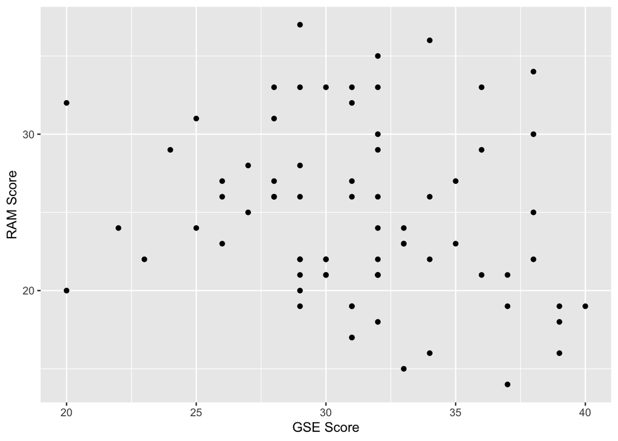

```r
# Scatterplots with labeled axes
ggplot(lab_data, aes(x = GSE_scale, y = RAM_scale)) +
  geom_point() +
  labs(
    x = "GSE Score",y = "RAM Score"
    )
```

## Primary Analysis: 2 x 2 ANOVAs

#### DV: Self-Efficacy

A 2 x 2 ANOVA tested the effects of feedback type and parental warmth on self-efficacy, and the interaction of these variables.

```r
# 2x2 between-subjects ANOVA predicting Self-Efficacy scores
# DV: GSE_scale
# Factors: Condition and pwarmth
a1_GSE <- afex::aov_ez(
  id = "id",
  dv = "GSE_scale",
  between = c("Condition", "pwarmth"),
  data = lab_data
  )
```

```
Converting to factor: Condition, pwarmth
```

```
Contrasts set to contr.sum for the following variables: Condition, pwarmth
```

```r
# Print the ANOVA table
a1_GSE
```

```
Anova Table (Type 3 tests)

Response: GSE_scale
             Effect    df   MSE    F   ges p.value
1         Condition 1, 72 19.94 0.07 <.001    .791
2           pwarmth 1, 72 19.94 0.01 <.001    .940
3 Condition:pwarmth 1, 72 19.94 1.02  .014    .315
---
Signif. codes:  0 '***' 0.001 '**' 0.01 '*' 0.05 '+' 0.1 ' ' 1
```

Main and interaction effects for feedback type (autonomy-supportive vs. controlling) and parental warmth (high vs. low) on self-efficacy. Feedback type did not have a significant effect on self-efficacy. Parental warmth did not have a significant effect on self-efficacy. There was no significant interaction effect.

#### Estimated Means for Self-Efficacy

Marginal means for feedback type (autonomy-supportive vs. controlling) self-efficacy.

```r
# Marginal (group) means for feedback condition
# Averaged across levels of parental warmth
emmeans(a1_GSE, ~ Condition)
```

```
NOTE: Results may be misleading due to involvement in interactions
```

```
 Condition emmean    SE df lower.CL upper.CL
 Autonomy    31.0 0.751 72     29.5     32.5
 Control     31.3 0.751 72     29.8     32.8

Results are averaged over the levels of: pwarmth
Confidence level used: 0.95
```

Marginal means for parental warmth (high vs. low) on self-efficacy.

```r
# Marginal (group) means for parental warmth
# Averaged across levels of feedback condition
emmeans(a1_GSE, ~ pwarmth)
```

```
NOTE: Results may be misleading due to involvement in interactions
```

```
 pwarmth emmean    SE df lower.CL upper.CL
 high      31.2 0.645 72     29.9     32.5
 low       31.1 0.844 72     29.4     32.8

Results are averaged over the levels of: Condition
Confidence level used: 0.95
```

Cell means for feedback type (autonomy-supportive vs. controlling) and parental warmth (high vs. low) on self-efficacy.

```r
# Raw estimated marginal means for each combination of condition and parental warmth
emmeans(a1_GSE, ~ Condition * pwarmth)
```

```
 Condition pwarmth emmean    SE df lower.CL upper.CL
 Autonomy  high      31.6 0.911 72     29.8     33.4
 Control   high      30.8 0.911 72     29.0     32.6
 Autonomy  low       30.4 1.190 72     28.0     32.8
 Control   low       31.8 1.190 72     29.4     34.2

Confidence level used: 0.95
```

#### DV: Achievement Motivation

A 2 x 2 ANOVA tested the effects of feedback type and parental warmth on achievement motivation, and the interaction of these variables.

```r
# 2x2 between-subjects ANOVA predicting Achievement Motivation scores
# DV: RAM_scale
# Factors: Condition and pwarmth
a1_RAM <- afex::aov_ez(
  id = "id",
  dv = "RAM_scale",
  between = c("Condition", "pwarmth"),
  data = lab_data
  )
```

```
Converting to factor: Condition, pwarmth
```

```
Contrasts set to contr.sum for the following variables: Condition, pwarmth
```

```r
# Print the ANOVA table
a1_RAM
```

```
Anova Table (Type 3 tests)

Response: RAM_scale
             Effect    df   MSE      F   ges p.value
1         Condition 1, 72 29.92   0.02 <.001    .902
2           pwarmth 1, 72 29.92 2.88 +  .038    .094
3 Condition:pwarmth 1, 72 29.92   0.00 <.001    .945
---
Signif. codes:  0 '***' 0.001 '**' 0.01 '*' 0.05 '+' 0.1 ' ' 1
```

Main and interaction effects for feedback type (autonomy-supportive vs. controlling) and parental warmth (high vs. low) on achievement motivation. Feedback type and parental warmth did not have significant effects on achievement motivation. There was not a significant interaction effect on achievement motivation.

#### Estimated Means for Achievement Motivation

Marginal means for feedback type (autonomy-supportive vs. controlling) on achievement motivation.

```r
# Marginal (group) means for feedback condition
# Averaged across levels of parental warmth
emmeans(a1_RAM, ~ Condition)
```

```
NOTE: Results may be misleading due to involvement in interactions
```

```
 Condition emmean   SE df lower.CL upper.CL
 Autonomy    24.3 0.92 72     22.4     26.1
 Control     24.4 0.92 72     22.6     26.3

Results are averaged over the levels of: pwarmth
Confidence level used: 0.95
```

Marginal means for parental warmth (high vs. low) on achievement motivation.

```r
# Marginal (group) means for parental warmth
# Averaged across levels of feedback condition
emmeans(a1_RAM, ~ pwarmth)
```

```
NOTE: Results may be misleading due to involvement in interactions
```

```
 pwarmth emmean   SE df lower.CL upper.CL
 high      25.5 0.79 72     23.9     27.0
 low       23.2 1.03 72     21.2     25.3

Results are averaged over the levels of: Condition
Confidence level used: 0.95
```

Interaction means for feedback type (autonomy-supportive vs. controlling) and parental warmth (high vs. low) on achievement motivation.

```r
# Raw estimated marginal means for each combination of condition and parental warmth
emmeans(a1_RAM, ~ Condition * pwarmth)
```

```
 Condition pwarmth emmean   SE df lower.CL upper.CL
 Autonomy  high      25.3 1.12 72     23.1     27.6
 Control   high      25.6 1.12 72     23.4     27.8
 Autonomy  low       23.2 1.46 72     20.3     26.1
 Control   low       23.3 1.46 72     20.4     26.2

Confidence level used: 0.95
```

## Figures

This section creates bar plots for the 2 x 2 ANOVA results and estimated means to help readers visualize the results.

#### Self-Efficacy Interaction Bar Plot

Bar graph for interaction of feedback type (autonomy-supportive vs. controlling) and parental warmth (high vs. low) on self-efficacy. Error bars represent 95% confidence intervals.

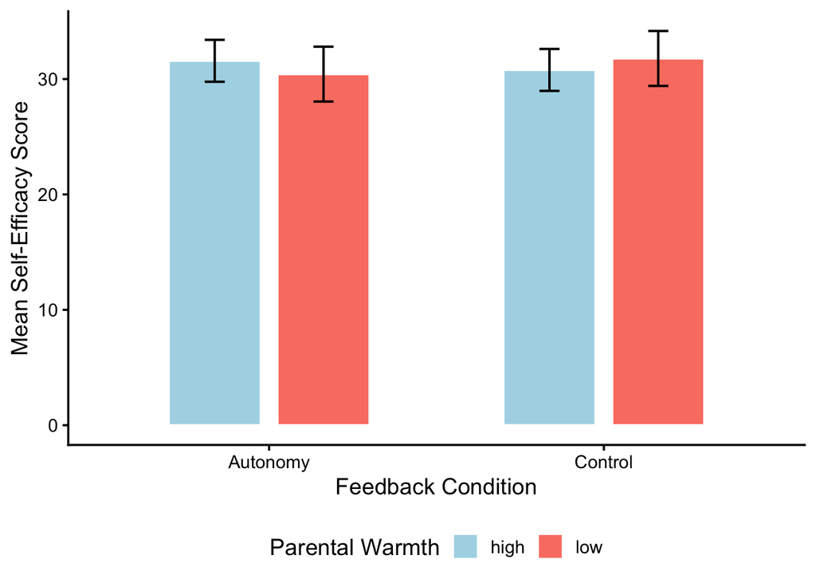

```r
 p_GSE_bar <- ggplot(
  as.data.frame(emmeans(a1_GSE, ~ Condition * pwarmth)),
  aes(
    x = Condition,
    y = emmean,
    fill = pwarmth
  )
) +
  geom_col(
    position = position_dodge(width = 0.65),
    width = 0.55,
    color = "white"
  ) +
  geom_errorbar(
    aes(
      ymin = lower.CL,
      ymax = upper.CL
    ),
    position = position_dodge(width = 0.65),
    width = 0.12,
    linewidth = 0.7
  ) +
  labs(
    x = "Feedback Condition",
    y = "Mean Self-Efficacy Score",
    fill = "Parental Warmth"
  ) +
  theme_classic(base_size = 14) +
  theme(legend.position = "bottom")+
   scale_fill_manual(values = c("lightblue", "salmon"))

print(p_GSE_bar)
```

#### Achievement Motivation Interaction Bar Plot

Bar graph for interaction of feedback type (autonomy-supportive vs. controlling) and parental warmth (high vs. low) on achievement motivation. Error bars represent 95% confidence intervals.

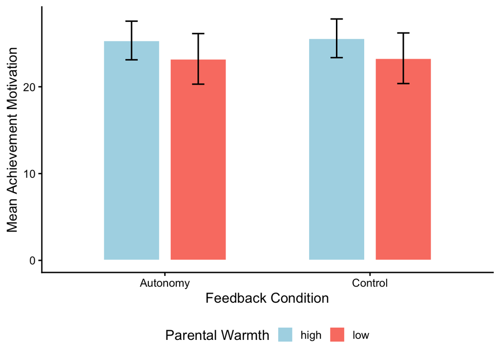

```r
p_RAM_bar <- ggplot(
  as.data.frame(emmeans(a1_RAM, ~ Condition * pwarmth)),
  aes(
    x = Condition,
    y = emmean,
    fill = pwarmth
  )
) +
  geom_col(
    position = position_dodge(width = 0.65),
    width = 0.55,
    color = "white"
  ) +
  geom_errorbar(
    aes(
      ymin = lower.CL,
      ymax = upper.CL
    ),
    position = position_dodge(width = 0.65),
    width = 0.12,
    linewidth = 0.7
  ) +
  labs(
    x = "Feedback Condition",
    y = "Mean Achievement Motivation",
    fill = "Parental Warmth"
  ) +
  theme_classic(base_size = 14) +
  theme(legend.position = "bottom")+
   scale_fill_manual(values = c("lightblue", "salmon"))


print(p_RAM_bar)
```

#### Exporting Figures

Self-efficacy and achievement motivation bar plots saved in “figures” folder for later use.

```r
# Create figures folder if needed
if (!dir.exists("figures")) dir.create("figures")

# Save whichever plots you want (SVG format for posters)
ggsave("figures/Self-Efficacy_bar_plot.svg", plot = p_GSE_bar, width = 7, height = 5)
```

```r
# Create figures folder if needed
if (!dir.exists("figures")) dir.create("figures")

# Save whichever plots you want (SVG format for posters)
ggsave("figures/AchievementMotivation_bar_plot.svg", plot = p_RAM_bar, width = 7, height = 5)
```

## Results Summary

The primary analyses tested whether feedback condition, parental warmth, and their interaction predicted self-efficacy and achievement motivation scores. For both 2 × 2 ANOVAs run, feedback condition was not a statistically significant predictor of either dependent variable.

These results indicate that participants who received autonomy-supportive feedback did not significantly differ in self-efficacy or achievement motivation compared to participants who received controlling feedback. Participants with high or low parental warmth also did not significantly differ in levels of self-efficacy and achievement motivation.

The main hypotheses were not statistically supported because feedback type and level of parental warmth did not independently predict self-efficacy and achievement motivation. Similarly, the interaction hypothesis was not supported because parental warmth did not significantly moderate the effects of the feedback type.